The format of this lab follows the same format as the previous ones. Your goal is to predict the value of the third column (which will be missing on the test set) using the techniques we have learned so far.

**One special rule this time: You are absolutely forbidden to create new variables by hand. If I find, for example, that you created a “flush” column or a column “max card” you’ll get a zero for the lab.**

# Set up

```r
library(readr)
library(dplyr)
```

```r
library(ggplot2)
library(viridis)
library(glmnet)
library(keras)
poker <- read_csv("https://statsmaths.github.io/ml_data/poker_hands.csv")
```

```
## `curl` package not installed, falling back to using `url()`
```

Your assignment will be scored using RMSE.

# Lab 12

Let us start with first creating the matrices for our data set and partitioning them based on our valid and train data sets.

```r
X <- model.matrix(~ . -1, data=poker[,4:13])
y <- poker$quality

X_train <- X[poker$train_id == "train",]
X_valid <- X[poker$train_id == "valid",]

y_train <- to_categorical(y[poker$train_id == "train"], num_classes = 10)
y_valid <- to_categorical(y[poker$train_id == "valid"], num_classes = 10)

head(X_train)
```

```
##    suit_1 number_1 suit_2 number_2 suit_3 number_3 suit_4 number_4 suit_5
## 1       4        8      4        9      1       10      1       13      2
## 2       2       10      1       10      4        6      1        8      4
## 3       4        3      4       13      1       13      4        8      1
## 5       4        5      2        3      3        2      2        5      3
## 10      3       11      3        8      4        8      3        5      3
## 11      3       12      3        6      2        8      2        7      1
##    number_5
## 1         7
## 2        14
## 3        12
## 5         5
## 10        7
## 11       10
```

From the table below we see that our data set is significantly unbalanced since the majority of our data considers a much higher number of lower quality data. This may indicate that a dense neural network may be the most appropriate model for our data.

```r
table(poker$train_id, poker$quality)
```

```
##
##              0      1      2      3      4      5      6      7      8
##   test       0      0      0      0      0      0      0      0      0
##   train 307941 260167  29377  12869   2377   1247    877    132     12
##   valid 102826  86597   9651   4390    773    407    315     42      1
##
##              9
##   test       0
##   train      7
##   valid      0
```

Next, we attempt to fit a neural network to the model. The reason why I believe this will be the most accurate model is because the network is notoriously good for finding complex interactions between predictor variables. In this case, determining why a flush is better than a straight or why having more of the same type of card in a hand is better than less.

```r
model1 <- keras_model_sequential()
model1 %>%
  layer_dense(units = 40, input_shape = c(10)) %>%
  layer_activation(activation = "relu") %>%
  layer_dense(units = 30) %>%
  layer_activation(activation = "relu") %>%
  layer_dense(units = 20) %>%
  layer_activation(activation = "relu") %>%
  layer_dense(units = 10) %>%
  layer_activation(activation = "softmax")
model1
```

```
## Model
## ___________________________________________________________________________
## Layer (type)                     Output Shape                  Param #
## ===========================================================================
## dense_1 (Dense)                  (None, 40)                    440
## ___________________________________________________________________________
## activation_1 (Activation)        (None, 40)                    0
## ___________________________________________________________________________
## dense_2 (Dense)                  (None, 30)                    1230
## ___________________________________________________________________________
## activation_2 (Activation)        (None, 30)                    0
## ___________________________________________________________________________
## dense_3 (Dense)                  (None, 20)                    620
## ___________________________________________________________________________
## activation_3 (Activation)        (None, 20)                    0
## ___________________________________________________________________________
## dense_4 (Dense)                  (None, 10)                    210
## ___________________________________________________________________________
## activation_4 (Activation)        (None, 10)                    0
## ===========================================================================
## Total params: 2,500
## Trainable params: 2,500
## Non-trainable params: 0
## ___________________________________________________________________________
```

I found that creating a more dense neural network led to a worse validation accuracy since the very dense networks typically restricted their predictions to mostly 0’s, if not all. Therefore, after playing around with the number of neurons, I found the following to consistently have higher validation accuracies.

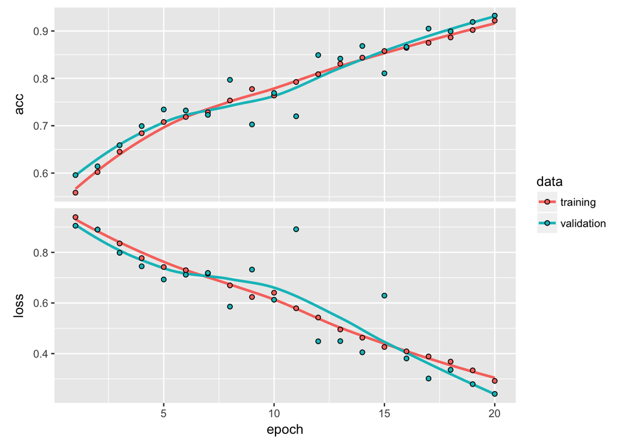

```r
model1 %>% compile(loss = 'categorical_crossentropy',
                  optimizer = optimizer_rmsprop(lr = 0.001),
                  metrics = c('accuracy'))

history <- model1 %>% fit(
  X_train, y_train,
  epochs = 20,
  validation_data = list(X_valid, y_valid),
)

plot(history)
```

```r
poker$quality_pred <- predict_classes(model1, x = X)
table(y= poker$quality, y_pred = poker$quality_pred)
```

```
##    y_pred
## y        0      1      2      3      6
##   0 410337    430      0      0      0
##   1  22465 324057    242      0      0
##   2      0  15950  22801    277      0
##   3      0    829   9179   7251      0
##   4   3069     81      0      0      0
##   5   1649      5      0      0      0
##   6      0      0     91   1094      7
##   7      0      0      0    157     17
##   8     12      1      0      0      0
##   9      7      0      0      0      0
```

```r
sqrt(tapply((poker$quality - poker$quality_pred)^2, poker$train_id, mean))
```

```
##      test     train     valid
##        NA 0.4403285 0.4359941
```

# Submission

The code below assumes that you have added a prediction named `quality_pred` to every row of the dataset.

```r
submit <- select(poker, obs_id, quality_pred)
write_csv(submit, "class12_submit.csv")
```

Now, upload this file (ends with “.Rmd”), the HTML output (ends with “.nb.html” or “.html”), and the csv file to GitHub.